# CourseProject-RegModels

### Executive Summary

```
##
##  Welch Two Sample t-test
##
## data:  mpg by am
## t = -3.767, df = 18.33, p-value = 0.001374
## alternative hypothesis: true difference in means is not equal to 0
## 95 percent confidence interval:
##  -11.28  -3.21
## sample estimates:
## mean in group automatic    mean in group manual
##                   17.15                   24.39
```

An analysis was done on a data set of a collection of cars, We were interested in exploring the relationship between different varibales from a set of eleven variables, and mile per gallon(MPG). Dataset from the 1974 Motor Trend has been used to find the answers to these two questions:

```
Is an automatic or manual transmission better for MPG
"Quantify the MPG difference between automatic and manual transmissions"
```

By incorporating hypothesis testing and simple linear regression, it is determined that there is significant difference between the mean MPG for automatic and manual transmission cars, on average manual transmission cars have 7.2449 more MPG. Moreover, in order to regulate for other confounding variables such as weight, Number of cylinders and horsepower of the car, multivariate regression model is used to find out the impact of other variables on MPG.Simple and multivariate regression models were validated by using ANOVA test. Results from the multivariate regression disclose that on average manual transmission cars get 1.81 miles more per gallon as compare to automatic transmission cars.

### Regression Analysis

#### Simple Linear Regression Model

```
##
## Call:
## lm(formula = mpg ~ am, data = mtcars)
##
## Residuals:
##    Min     1Q Median     3Q    Max
## -9.392 -3.092 -0.297  3.244  9.508
##
## Coefficients:
##             Estimate Std. Error t value Pr(>|t|)
## (Intercept)    17.15       1.12   15.25  1.1e-15 ***
## ammanual        7.24       1.76    4.11  0.00029 ***
## ---
## Signif. codes:  0 '***' 0.001 '**' 0.01 '*' 0.05 '.' 0.1 ' ' 1
##
## Residual standard error: 4.9 on 30 degrees of freedom
## Multiple R-squared:  0.36,   Adjusted R-squared:  0.338
## F-statistic: 16.9 on 1 and 30 DF,  p-value: 0.000285
```

Null hypothesis is rejected and it can be said that, there exists a linear relation between the predictor variable mpg and am.Intercepts and Coefficient can be explained that, on average automatic transmission cars has 17.1474 MPG and manual transmission cars has 24.3923 ( 17.1474 + 7.2449 ).The value of R^2 is 0.3598, which means this model only explain 36% of the variance.

#### Multivariate Regression Model

##### Best Regression Model

In order to choose the best model, we use the stepwise selection (forward, backward, both) using the stepAIC( ) function from the MASS package.

```
## Start:  AIC=76.4
## mpg ~ cyl + disp + hp + drat + wt + qsec + vs + am + gear + carb
##
##        Df Sum of Sq RSS  AIC
## - carb  5     13.60 134 69.8
## - gear  2      3.97 124 73.4
## - am    1      1.14 122 74.7
## - qsec  1      1.24 122 74.7
## - drat  1      1.82 122 74.9
## - cyl   2     10.93 131 75.2
## - vs    1      3.63 124 75.4
## <none>              120 76.4
## - disp  1      9.97 130 76.9
## - wt    1     25.55 146 80.6
## - hp    1     25.67 146 80.6
##
## Step:  AIC=69.83
## mpg ~ cyl + disp + hp + drat + wt + qsec + vs + am + gear
##
##        Df Sum of Sq RSS  AIC
## - gear  2      5.02 139 67.0
## - disp  1      0.99 135 68.1
## - drat  1      1.19 135 68.1
## - vs    1      3.68 138 68.7
## - cyl   2     12.56 147 68.7
## - qsec  1      5.26 139 69.1
## <none>              134 69.8
## - am    1     11.93 146 70.6
## - wt    1     19.80 154 72.2
## - hp    1     22.79 157 72.9
## + carb  5     13.60 120 76.4
##
## Step:  AIC=67
## mpg ~ cyl + disp + hp + drat + wt + qsec + vs + am
##
##        Df Sum of Sq RSS  AIC
## - drat  1      0.97 140 65.2
## - cyl   2     10.42 149 65.3
## - disp  1      1.55 141 65.4
## - vs    1      2.18 141 65.5
```

[output cut: 56 more lines]

```
## Step:  AIC=61.65
## mpg ~ cyl + hp + wt + am
##
##        Df Sum of Sq RSS  AIC
## <none>              151 61.7
## - am    1       9.8 161 61.7
## + vs    1       7.3 144 62.1
## + qsec  1       7.0 144 62.1
## - cyl   2      29.3 180 63.3
## + disp  1       0.6 150 63.5
## + drat  1       0.2 151 63.6
## + gear  2       1.4 150 65.4
## - hp    1      31.9 183 65.8
## - wt    1      46.2 197 68.2
## + carb  5       5.6 145 70.4
```

##### Analysis of variances (ANOVA Test)

We now derive from the anova for different cases involving a. transmission, b. all variables and c. best fit variable combination of predictors cyl, hp, wt and am.

```
## Analysis of Variance Table
##
## Model 1: mpg ~ cyl + disp + hp + drat + wt + qsec + vs + am + gear + carb
## Model 2: mpg ~ am
## Model 3: mpg ~ cyl + hp + wt + am
##   Res.Df RSS  Df Sum of Sq     F  Pr(>F)
## 1     15 120
## 2     30 721 -15      -600  4.99  0.0018 **
## 3     26 151   4       570 17.75 1.5e-05 ***
## ---
## Signif. codes:  0 '***' 0.001 '**' 0.01 '*' 0.05 '.' 0.1 ' ' 1
```

With the p-value 1.5e-05, null hypothesis is rejected and it can be claimed that the multivariate model of regression is significantly different from that of simple model.

##### Residual - Diagnostics Analysis

Please see the residual plots for the chosen regression model (Appendix). We can conclude the following from the plot:

```
The points in the Residuals vs Fitted plot are randomly scattered with no particular pattern.
The points in the Normal QQ plot are more-or-less on the line, indicating that the residuals follow a normal distribution.
In both the ScaleLocation plot and the Residuals vs Leverage plots, the points are in a group with none too far from the center.
```

After examing the plots, we can say that residuals are normally distributed and are homoskedastic. Now estimates from the multivariate model can be interpreted.

```
## (Intercept)        cyl6        cyl8          hp          wt    ammanual
##    33.70832    -3.03134    -2.16368    -0.03211    -2.49683     1.80921
```

```
## (Intercept)        cyl6        cyl8
##      26.664      -6.921     -11.564
```

Multivariate regression model explain 86.588% variance. Furthermore it can be seen that wt and to some extent hp confound the relationship between am and mpg.On Average manual transmission cars has 1.8092 MPGs more than automatic transmission cars. It is concluded that, it is better for MPG to have manual transmission cars vs automatic cars.

### Conclusions

From our multiple regression analysis above, we conclude the following:

[output not shown]

### Appendix

##### Exploratory Data Analysis

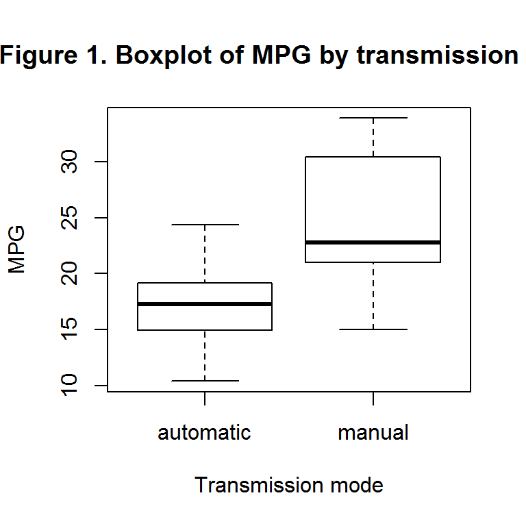

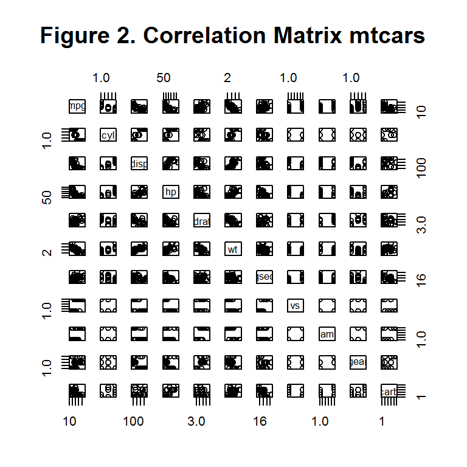

##### Regression Analysis Plots

##### Residual plots for the regression model

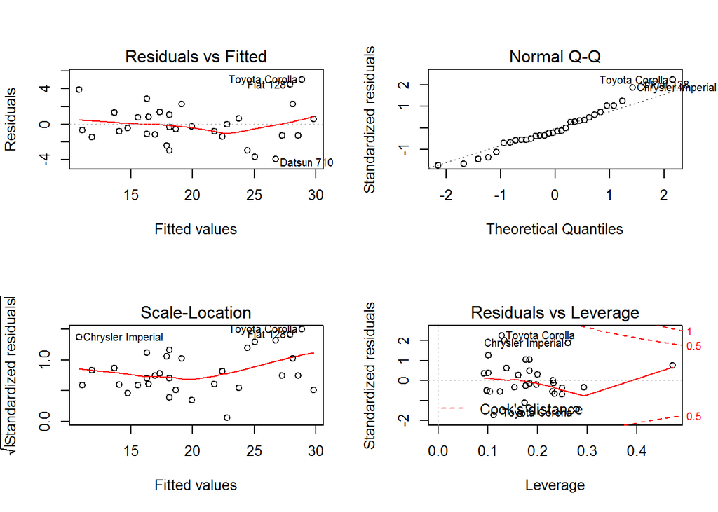

##### Cooks Distance plot for the regression model

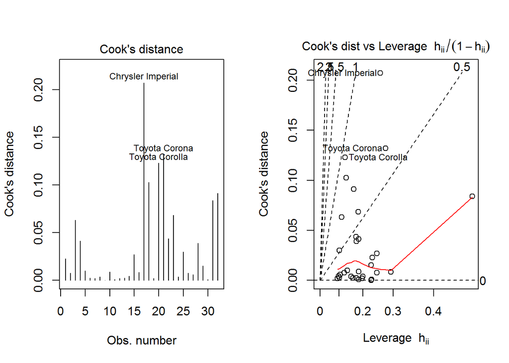

#### Diagnostics

We want to identify the impact of an observation on the regression coefficients, and one approach is to consider how much the regression coefficient values change if the observation was not considered.

```
##       Maserati Bora Lincoln Continental       Toyota Corona
##              0.4714              0.2937              0.2778
```

Please see the appendix section for the cooks distance plot for the chosen regression model.

```
##    Toyota Corolla     Toyota Corona Chrysler Imperial
##            0.1229            0.1320            0.2072
```

From the cooks distance plot above we can confirm our analysis was correct, as the same cars are mentioned in the residual plots.